# Portfolio assignment 2, part 2

MARTIN THOMSEN

14-11-2021

# Exercises and objectives

The objectives of the exercises of this assignment are based on: https://doi.org/10.1016/j.concog.2019.03.007

4. Download and organise the data from experiment 1
5. Use log-likelihood ratio tests to evaluate logistic regression models
6. Test linear hypotheses
7. Estimate psychometric functions for the Perceptual Awareness Scale and evaluate them

REMEMBER: In your report, make sure to include code that can reproduce the answers requested in the exercises below (**MAKE A KNITTED VERSION**)  
REMEMBER: This is part 2 of Assignment 2 and will be part of your final portfolio

# EXERCISE 4 - Download and organise the data from experiment 1

Go to https://osf.io/ecxsj/files/ and download the files associated with Experiment 1 (there should be 29).  
The data is associated with Experiment 1 of the article at the following DOI https://doi.org/10.1016/j.concog.2019.03.007

1. Put the data from all subjects into a single data frame - note that some of the subjects do not have the *seed* variable. For these subjects, add this variable and make in *NA* for all observations. (The *seed* variable will not be part of the analysis and is not an experimental variable)

```r
experiment_df = read_bulk("experiment_1")
```

[output not shown]

[output not shown]

[output not shown]

[output not shown]

[output not shown]

[output not shown]

[output not shown]

[output not shown]

[output not shown]

[output not shown]

[output not shown]

[output not shown]

[output not shown]

[output not shown]

[output not shown]

[output not shown]

[output not shown]

[output not shown]

[output not shown]

[output not shown]

[output not shown]

[output not shown]

[output not shown]

[output not shown]

[output not shown]

[output not shown]

[output not shown]

[output not shown]

[output not shown]

```
i. Factorise the variables that need factorising
```

```r
experiment_df$trial.type = factor(experiment_df$trial.type)
experiment_df$cue = factor(experiment_df$cue)
experiment_df$task = factor(experiment_df$task)
experiment_df$pas = factor(experiment_df$pas)
experiment_df$subject = factor(experiment_df$subject)
```

```
ii. Remove the practice trials from the dataset (see the _trial.type_ variable)
```

```r
trial_df <- subset(experiment_df, experiment_df$trial.type == "experiment")
```

```
iii. Create a _correct_ variable
```

```r
# Create variable and set all to 0
trial_df$correct = 0

# Loop through data and change "correct" to 1 where response matches target type
for(i in 1:length(trial_df$trial.type))
{

    if (trial_df$obj.resp[i]== 'o' && trial_df$target.type[i] == 'odd')
    {
     trial_df$correct[i] = 1
    }

    else if(trial_df$obj.resp[i]== 'e' && trial_df$target.type[i] == 'even'){
    trial_df$correct[i] = 1
    }

}
```

```
iv. Describe how the _target.contrast_ and _target.frames_ variables differ compared to the data from part 1 of this assignment
In the first part of the experiment target frames were kept fixed at 3, whereas the target contrast varied. In the second part, the target contrast is kept constant at 0.1 and target fram varies between 1 and 6.
```

# EXERCISE 5 - Use log-likelihood ratio tests to evaluate logistic regression models

1. Do logistic regression - *correct* as the dependent variable and *target.frames* as the independent variable. (Make sure that you understand what *target.frames* encode). Create two models - a pooled model and a partial-pooling model. The partial-pooling model should include a subject-specific intercept.

```r
pooled_model = glm(correct ~ target.frames, data = trial_df, family = binomial)
partial_model = glmer(correct ~ target.frames + (1|subject), data = trial_df, family = binomial)
```

```
i. the likelihood-function for logistic regression is: $L(p)={\displaystyle\prod_{i=1}^Np^{y_i}(1-p)^{(1-y_i)}}$ (Remember the probability mass function for the Bernoulli Distribution). Create a function that calculates the likelihood.
```

```r
# Creating a likelihood function, which takes a model and a vector as input
likelihood_fun <- function(model, y)
  {
  p <- fitted(model) # extract fitted values

  return(prod(p^y*(1-p)^(1-y)))
  }
```

```
ii. the log-likelihood-function for logistic regression is: $l(p) = {\displaystyle\sum_{i=1}^N}[y_i\ln{p}+(1-y_i)\ln{(1-p)}$. Create a function that calculates the log-likelihood
```

```r
# Creating a logarithmic likelihood function, which takes a model and a vector as input
log_likelihood_fun <- function(model, y)
  {
  p <- fitted(model) # extract fitted values

  return(sum(y*log(p)+(1-y)*log(1-p)))
  }
```

[output not shown]

```r
likelihood_fun(pooled_model, trial_df$correct)
```

```
## [1] 0
```

```r
log_likelihood_fun(pooled_model, trial_df$correct)
```

```
## [1] -10865.25
```

```r
logLik(pooled_model)
```

```
## 'log Lik.' -10865.25 (df=2)
```

The likelihood function carries out a lot of multiplications of values below 1. As such, the result will converge on zero. Instead, the log likelihood function will transform the data before multiplication, avoiding the convergence on zero. iv. now show that the log-likelihood is a little off when applied to the partial pooling model - (the likelihood function is different for the multilevel function - see section 2.1 of https://www.researchgate.net/profile/Douglas-Bates/publication/2753537_Computational_Methods_for_Multilevel_Modelling/links/00b4953b4108d73427000000/Computational-Methods-for-Multilevel-Modelling.pdf if you are interested)

```r
log_likelihood_fun(partial_model, trial_df$correct)
```

```
## [1] -10565.53
```

```r
logLik(partial_model)
```

```
## 'log Lik.' -10622.03 (df=3)
```

2. Use log-likelihood ratio tests to argue for the addition of predictor variables, start from the null model, `glm(correct ~ 1, 'binomial', data)`, then add subject-level intercepts, then add a group-level effect of *target.frames* and finally add subject-level slopes for *target.frames*. Also assess whether or not a correlation between the subject-level slopes and the subject-level intercepts should be included.

```r
# Creating models
null_model = glm(correct ~ 1, family = binomial, data = trial_df) # Null model
subject_model = glmer(correct ~ 1 +(1|subject), family = binomial, data = trial_df) # Added subject-level intercept ((1|subject))
target_frame_model = glmer(correct ~ target.frames + (1|subject), family = binomial, data = trial_df) # Target.frames added as group-level effect (target.frames)
slope_model = glmer(correct ~ target.frames + (target.frames|subject), family = binomial, data = trial_df) # Subject-level slopes for target.frames added (target.frames|subject)
correlation_model = glmer(correct ~ target.frames + (target.frames||subject), family = binomial, data = trial_df) # Honestly not sure if this is correct, I was having a difficult time finding documentation online

# Combining model names in order to provide a prettier output to reader
model = c("null_model", "subject_model", "target_frame_model", "slope_model", "correlation_model")
log_likelihood = c(logLik(null_model), logLik(subject_model), logLik(target_frame_model), logLik(slope_model), logLik(correlation_model))
# Display as combined data
cbind(model, log_likelihood)
```

```
##      model                log_likelihood
## [1,] "null_model"         "-13341.5389675954"
## [2,] "subject_model"      "-13157.5490854917"
## [3,] "target_frame_model" "-10622.0314964951"
## [4,] "slope_model"        "-10448.8251446072"
## [5,] "correlation_model"  "-10460.2881343783"
```

Assuming the correlation model has been modelled correctly, it has a log likelihood of -10460, whereas the slope model has a log likelihood of -10448. The higher the log likelihood, the better the model fits data. As such, the slop model is the superior model. i. write a short methods section and a results section where you indicate which model you chose and the statistics relevant for that choice. Include a plot of the estimated group-level function with `xlim=c(0, 8)` that includes the estimated subject-specific functions. The log likelihood values of the slope model and correlation model are very close to each other. Here, a comparison of the two models, to determine if the difference is significant, must be carried out. This can be done using the anova function.

```r
anova(slope_model, correlation_model)
```

|  | npar | AIC | BIC | logLik | deviance | Chisq | Df | Pr(>Chisq) |
| --- | --- | --- | --- | --- | --- | --- | --- | --- |
| correlation_model | 4 | 20928.58 | 20961.09 | -10460.29 | 20920.58 | NA | NA | NA |
| slope_model | 5 | 20907.65 | 20948.29 | -10448.83 | 20897.65 | 22.92598 | 1 | 1.683609e-06 |

```
The anova shows that the slope model is significantly different from the correlation model. This means that this model should be used going forward.
Plotting the group level function (the original pooled model) and the slope model (containing the subject specific level):
```

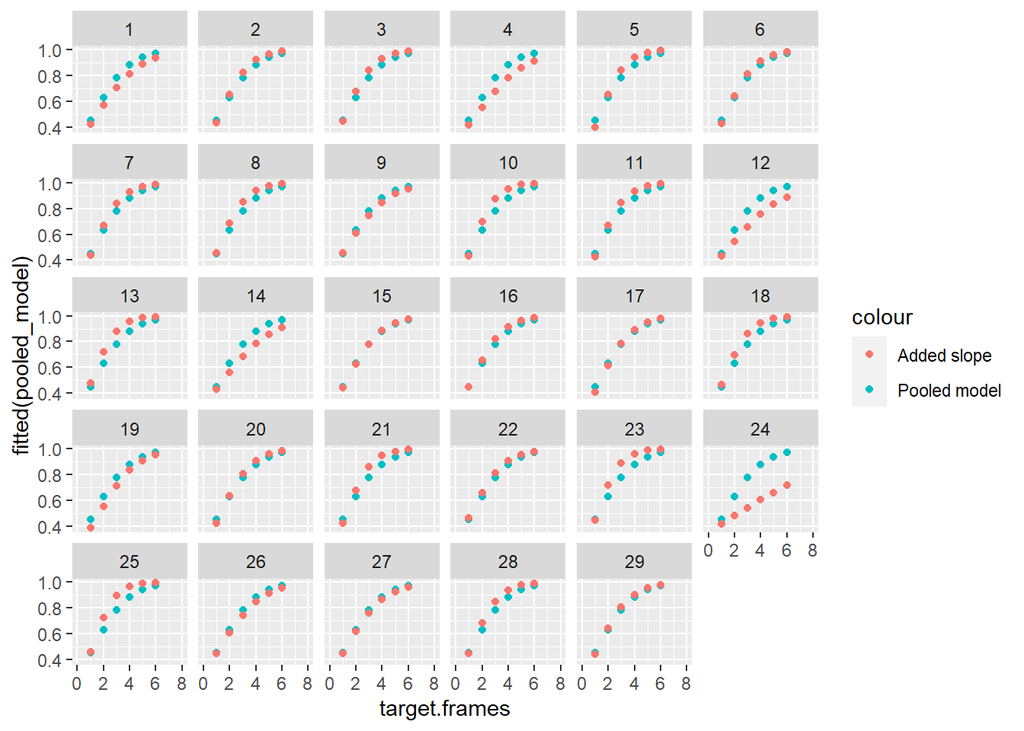

```r
# Plotting using ggplot
ggplot(data = trial_df) +
  geom_point(aes(x = target.frames, y = fitted(pooled_model), color = "Pooled model")) +
  geom_point(aes(x = target.frames, y = fitted(slope_model), color = "Added slope")) +
  facet_wrap( ~ subject) +
  xlim(0,8)
```

ii. also include in the results section whether the fit didn’t look good for any of the subjects. If so, identify those subjects in the report, and judge (no statistical test) whether their performance (accuracy) differed from that of the other subjects. Was their performance better than chance? (Use a statistical test this time) (50 %) Looking at the plots above, it appears that data on participants 12 and 24 is poorly fitted using the group level model. As we are looking at whether the performance was above chance:

```r
subject12_df = subset(trial_df, subject == "12")
subject24_df = subset(trial_df, subject == "24")

t.test(subject12_df$correct, mu = 0.5)
```

```
##
##  One Sample t-test
##
## data:  subject12_df$correct
## t = 11.629, df = 863, p-value < 2.2e-16
## alternative hypothesis: true mean is not equal to 0.5
## 95 percent confidence interval:
##  0.6529669 0.7150886
## sample estimates:
## mean of x
## 0.6840278
```

```r
t.test(subject24_df$correct, mu = 0.5)
```

```
##
##  One Sample t-test
##
## data:  subject24_df$correct
## t = 4.026, df = 873, p-value = 6.167e-05
## alternative hypothesis: true mean is not equal to 0.5
## 95 percent confidence interval:
##  0.5345964 0.6004150
## sample estimates:
## mean of x
## 0.5675057
```

Both performances were above chance, with a p-value < 0.05.

3. Now add *pas* to the group-level effects - if a log-likelihood ratio test justifies this, also add the interaction between *pas* and *target.frames* and check whether a log-likelihood ratio test justifies this

```r
pas_model = glmer(correct ~ target.frames + pas + (target.frames|subject), family = binomial, data = trial_df)
log_likelihood_fun(pas_model, trial_df$correct)
```

```
## [1] -9860.225
```

```r
interaction_model = glmer(correct ~ target.frames * pas + (target.frames|subject), family = binomial, data = trial_df)
logLik(interaction_model)
```

```
## 'log Lik.' -9742.039 (df=11)
```

```
i. if your model doesn't converge, try a different optimizer
```

```r
interaction_model = glmer(correct ~ target.frames * pas + (target.frames|subject), family = binomial, data = trial_df, control = glmerControl(optimizer="bobyqa"))
logLik(interaction_model)
```

```
## 'log Lik.' -9742.039 (df=11)
```

The log likelihood tests suggest that the model containing the target frames by pas interaction is the better model. This is supported by the anova test below, which shows that the interaction model is significantly better.

```r
anova(slope_model, pas_model, interaction_model)
```

|  | npar | AIC | BIC | logLik | deviance | Chisq | Df | Pr(>Chisq) |
| --- | --- | --- | --- | --- | --- | --- | --- | --- |
| slope_model | 5 | 20907.65 | 20948.29 | -10448.825 | 20897.65 | NA | NA | NA |
| pas_model | 8 | 19879.66 | 19944.68 | -9931.828 | 19863.66 | 1033.9934 | 3 | 7.599679e-224 |
| interaction_model | 11 | 19506.08 | 19595.49 | -9742.039 | 19484.08 | 379.5781 | 3 | 5.866734e-82 |

[output not shown]

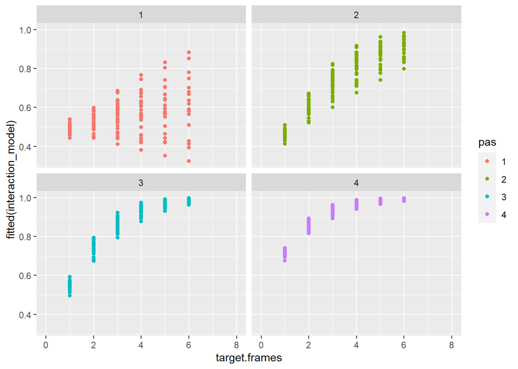

```r
# Plotting using ggplot
ggplot(data = trial_df) +
  geom_point(aes(x = target.frames, y = fitted(interaction_model), color = pas)) +
  facet_wrap( ~ pas) +
  xlim(0,8)
```

Only points have been plotted here and not a line. A line would have an intercept at x = 0 (i.e. at zero frames), which is meaningless. Instead, using points only, it is possible to see how accuracy is dependent on both the self-reported confidence and length of exposure to the stimuli. The span on accuracy is reduced the more certain participants rate themselves (pas = 4) and the accuracy is generally higher, regardless of the length of stimuli.

# EXERCISE 6 - Test linear hypotheses

In this section we are going to test different hypotheses. We assume that we have already proved that more objective evidence (longer duration of stimuli) is sufficient to increase accuracy in and of itself and that more subjective evidence (higher PAS ratings) is also sufficient to increase accuracy in and of itself.  
We want to test a hypothesis for each of the three neighbouring differences in PAS, i.e. the difference between 2 and 1, the difference between 3 and 2 and the difference between 4 and 3. More specifically, we want to test the hypothesis that accuracy increases faster with objective evidence if subjective evidence is higher at the same time, i.e. we want to test for an interaction.

1. Fit a model based on the following formula: `correct ~ pas * target.frames + (target.frames | subject))`
   1. First, use `summary` (yes, you are allowed to!) to argue that accuracy increases faster with objective evidence for PAS 2 than for PAS 1.

```r
summary(interaction_model)
```

```
## Generalized linear mixed model fit by maximum likelihood (Laplace
##   Approximation) [glmerMod]
##  Family: binomial  ( logit )
## Formula: correct ~ target.frames * pas + (target.frames | subject)
##    Data: trial_df
## Control: glmerControl(optimizer = "bobyqa")
##
##      AIC      BIC   logLik deviance df.resid
##  19506.1  19595.5  -9742.0  19484.1    25033
##
## Scaled residuals:
##      Min       1Q   Median       3Q      Max
## -19.0108   0.0537   0.1606   0.4849   1.4465
##
## Random effects:
##  Groups  Name          Variance Std.Dev. Corr
##  subject (Intercept)   0.03698  0.1923
##          target.frames 0.02058  0.1434   -0.76
## Number of obs: 25044, groups:  subject, 29
##
## Fixed effects:
##                    Estimate Std. Error z value Pr(>|z|)
## (Intercept)        -0.12163    0.06411  -1.897 0.057801 .
## target.frames       0.11480    0.03707   3.097 0.001955 **
## pas2               -0.57139    0.08937  -6.394 1.62e-10 ***
## pas3               -0.53850    0.13935  -3.864 0.000111 ***
## pas4                0.20159    0.24978   0.807 0.419619
## target.frames:pas2  0.44718    0.03473  12.878  < 2e-16 ***
## target.frames:pas3  0.74869    0.04589  16.314  < 2e-16 ***
## target.frames:pas4  0.75927    0.06830  11.116  < 2e-16 ***
## ---
## Signif. codes:  0 '***' 0.001 '**' 0.01 '*' 0.05 '.' 0.1 ' ' 1
##
## Correlation of Fixed Effects:
##             (Intr) trgt.f pas2   pas3   pas4   trg.:2 trg.:3
## target.frms -0.811
## pas2        -0.461  0.305
## pas3        -0.307  0.207  0.248
## pas4        -0.173  0.123  0.121  0.091
## trgt.frms:2  0.481 -0.428 -0.874 -0.244 -0.124
## trgt.frms:3  0.392 -0.358 -0.278 -0.891 -0.111  0.370
## trgt.frms:4  0.275 -0.260 -0.163 -0.120 -0.918  0.225  0.200
```

Accuracy increases with an increase in target frames by 0.115 and accuracy is clearly worse at pas = 2 and pas = 3 compared to pas = 1 and 4. However, the increase in accuracy for pas = 4 is insignificant (p = 0.42). The target frame by pas interaction shows that accuracy increases by 0.447, 0.749 and 0.76 respectively for pas = 2, 3 and 4 respectively.

2. `summary` won’t allow you to test whether accuracy increases faster with objective evidence for PAS 3 than for PAS 2 (unless you use `relevel`, which you are not allowed to in this exercise). Instead, we’ll be using the function `glht` from the `multcomp` package
   1. To redo the test in 6.1.i, you can create a *contrast* vector. This vector will have the length of the number of estimated group-level effects and any specific contrast you can think of can be specified using this. For redoing the test from 6.1.i, the code snippet below will do The purpose is to determine if the rate of accuracy increases more with target frames, at each level of pas. Therefore, the target frame by pas interaction will be compared for the different levels of pas.

```r
# Testing whether rate of accuracy as a result of target frames increases for pas 2 over pas 1
contrast.vector <- matrix(c(0, 0, 0, 0, 0, 1, 0, 0), nrow=1)
gh_1 <- glht(interaction_model, contrast.vector)
print(summary(gh_1))
# Testing whether rate of accuracy as a result of target frames increases for pas 3 over pas 2
contrast.vector <- matrix(c(0, 0, 0, 0, 0, -1, 1, 0), nrow=1)
gh_2 <- glht(m_target.pas.interact, contrast.vector)
print(summary(gh_2))

# Testing whether rate of accuracy as a result of target frames increases for pas 4 over pas 3
contrast.vector <- matrix(c(0, 0, 0, 0, 0, 0, -1, 1), nrow=1)
gh_3 <- glht(m_target.pas.interact, contrast.vector)
print(summary(gh_3))
```

[output not shown]

[output not shown]

3. Finally, test that whether the difference between PAS 2 and 1 (tested in 6.1.i) is greater than the difference between PAS 4 and 3 (tested in 6.2.iii) The difference between pas 3 and 4 is not significant and as such, the significant difference between pas 2 and 1 (0.447) is greater.

# EXERCISE 7 - Estimate psychometric functions for the Perceptual Awareness Scale and evaluate them

We saw in 5.3 that the estimated functions went below chance at a target duration of 0 frames (0 ms). This does not seem reasonable, so we will be trying a different approach for fitting here.  
We will fit the following function that results in a sigmoid, $f(x) = a + \frac {b - a} {1 + e^{\frac {c-x} {d}}}$  
It has four parameters: *a*, which can be interpreted as the minimum accuracy level, *b*, which can be interpreted as the maximum accuracy level, *c*, which can be interpreted as the so-called inflexion point, i.e. where the derivative of the sigmoid reaches its maximum and *d*, which can be interpreted as the steepness at the inflexion point. (When *d* goes towards infinity, the slope goes towards a straight line, and when it goes towards 0, the slope goes towards a step function).

We can define a function of a residual sum of squares as below

```r
RSS <- function(dataset, par)
{
    ## "dataset" should be a data.frame containing the variables x (target.frames)
    ## and y (correct)

    ## "par" are our four parameters (a numeric vector)
    a = par[1]
    b = par[2]
    c = par[3]
    d = par[4]
    x <- dataset$target.frames
    y <- dataset$correct
    y.hat <- a + ((b-a)/(1+exp(1)^((c-x)/d)))
    RSS <- sum((y - y.hat)^2)
    return(RSS)
}
```

1. Now, we will fit the sigmoid for the four PAS ratings for Subject 7

```r
subject_7 <- trial_df %>%
  filter(subject == "7") %>%
  dplyr::select(target.frames, correct, pas)
```

```
i. use the function `optim`. It returns a list that among other things contains the four estimated parameters. You should set the following arguments:
`par`: you can set _c_ and _d_ as 1. Find good choices for _a_ and _b_ yourself (and argue why they are appropriate)
As minimum accuracy should be chance, a = 0.5. Maximum accuracy is 1 and therefore b = 1.
```

```r
par = c(0.5,1,1,1)
```

```
`fn`: which function to minimise?
`data`: the data frame with _x_, _target.frames_, and _y_, _correct_ in it
`method`: 'L-BFGS-B'
`lower`: lower bounds for the four parameters, (the lowest value they can take), you can set _c_ and _d_ as `-Inf`. Find good choices for _a_ and _b_ yourself (and argue why they are appropriate)
Lower bound must be 0 as all probabilities must be between 0 and 1.
`upper`: upper bounds for the four parameters, (the highest value they can take) can set _c_ and _d_ as `Inf`. Find good choices for _a_ and _b_ yourself (and argue why they are appropriate)
As above, 1 is appropriate as all probabilities must fall between 0 and 1.
```

```r
subject7_pas1 = optim(data = filter(subject_7, pas == 1), fn = RSS, par = par, method = 'L-BFGS-B', lower = c(0, 0, -Inf, -Inf), upper = c(1, 1, Inf, Inf))
subject7_pas2 = optim(data = filter(subject_7, pas == 2), fn = RSS, par = par, method = 'L-BFGS-B', lower = c(0, 0, -Inf, -Inf), upper = c(1, 1, Inf, Inf))
subject7_pas3 = optim(data = filter(subject_7, pas == 3), fn = RSS, par = par, method = 'L-BFGS-B', lower = c(0, 0, -Inf, -Inf), upper = c(1, 1, Inf, Inf))
subject7_pas4 = optim(data = filter(subject_7, pas == 4), fn = RSS, par = par, method = 'L-BFGS-B', lower = c(0, 0, -Inf, -Inf), upper = c(1, 1, Inf, Inf))
```

```r
par_values = cbind(subject7_pas1$par,subject7_pas2$par,subject7_pas3$par,subject7_pas4$par)
```

[output not shown]

2. Finally, estimate the parameters for all subjects and each of their four PAS ratings. Then plot the estimated function at the group-level by taking the mean for each of the four parameters, *a*, *b*, *c* and *d* across subjects. A function should be estimated for each PAS-rating (it should look somewhat similar to Fig. 3 from the article: https://doi.org/10.1016/j.concog.2019.03.007)
   1. compare with the figure you made in 5.3.ii and comment on the differences between the fits - mention some advantages and disadvantages of both.